# BC Election 2009 - voting patterns

Martin Monkman

Sunday, November 23, 2014

# VOTER DEMOGRAPHICS

Replicating the charts in the report “Who heads to the polls? Exploring the Demographics of Voters in British Columbia” (March 2010, BC Stats for Elections BC)

#### Some background reading material regarding back-to-back bar charts

http://www.r-bloggers.com/ggplot2-a-little-twist-on-back-to-back-bar-charts/ http://learnr.wordpress.com/2009/09/24/ggplot2-back-to-back-bar-charts/ http://svitsrv25.epfl.ch/R-doc/library/Hmisc/html/histbackback.html

#### Reshape and summarise the data

First, take the “wide” table and convert it into “long” layout using the `melt` function.

Second, create variables that describe the 2009 voting behaviour, and the consistency of the behaviour and status on the list. These are as follows:

- consistent (on the list in 2001, 2005, and 2009 and exhibiting consistent voting behaviour),
- inconsistent – on the list in all three years or (in rare cases) on the list in either 2001 and 2005, and exhibiting inconsistent voting behaviour, and
- newly eligible (appearing on the list for the first time in 2009).

```
##        AGE      variable value  vote09    pattern
## 1 18 to 19 NV.Consistent     0 NonVote Consistent
## 2 20 to 24 NV.Consistent     3 NonVote Consistent
## 3 25 to 29 NV.Consistent  4354 NonVote Consistent
## 4 30 to 34 NV.Consistent 16783 NonVote Consistent
## 5 35 to 39 NV.Consistent 21619 NonVote Consistent
## 6 40 to 44 NV.Consistent 25366 NonVote Consistent
```

#### Summary Tables

Now create summary tables of the data.

The second is by the voting pattern “variable”. We need both the sum of each voting pattern group and the relative requency of that group (i.e. the percentage of the total). Note that this approach uses the `dplr` package.

(See [here](http://stackoverflow.com/questions/24576515/relative-frequency-with-dplyr).)

```r
# "totalall" is the number of voters on the list in 2009
totalall <- BCdata_long %>%
  summarise(totalall = sum(value))
totalall <- as.numeric(totalall)


# summarise the data by voting pattern "pattern"
table_pattern <- BCdata_long %>%
  group_by(pattern) %>%
  summarise(total = sum(value)) %>%
  mutate(freq = 100 * (total / sum(total)))
table_pattern
```

```
## Source: local data frame [3 x 3]
##
##         pattern   total     freq
## 1    Consistent 1138359 38.00285
## 2  Inconsistent  708180 23.64180
## 3 NewlyEligible 1148918 38.35535
```

```r
# summarise the data by voting behaviour "vote09"
table_vote <- BCdata_long %>%
  group_by(vote09) %>%
  summarise(total = sum(value)) %>%
  mutate(freq = 100 * (total / sum(total)))
table_vote
```

```
## Source: local data frame [2 x 3]
##
##    vote09   total     freq
## 1 NonVote 1344987 44.90089
## 2    Vote 1650470 55.09911
```

```r
# summarise the data by voting pattern "pattern" and "vote09"
table_votepattern <- BCdata_long %>%
  group_by(vote09, pattern) %>%
  summarise(total = sum(value)) %>%
  mutate(freq = (100 * (total / totalall)))
table_votepattern
```

```
## Source: local data frame [6 x 4]
## Groups: vote09
##
##    vote09       pattern  total      freq
## 1 NonVote    Consistent 183147  6.114159
## 2 NonVote  Inconsistent 421611 14.075014
## 3 NonVote NewlyEligible 740229 24.711722
## 4    Vote    Consistent 955212 31.888690
## 5    Vote  Inconsistent 286569  9.566787
## 6    Vote NewlyEligible 408689 13.643628
```

An alternate table, based on the original “variable” (which contains both voting and consistency information).

```r
# summarise the data by voting pattern "variable"
plot2data <- BCdata_long %>%
  group_by(variable) %>%
  summarise(total = sum(value)) %>%
  mutate(freq = 100 * (total / sum(total)))
plot2data
```

```
## Source: local data frame [6 x 3]
##
##           variable  total      freq
## 1    NV.Consistent 183147  6.114159
## 2  NV.Inconsistent 421611 14.075014
## 3 NV.NewlyEligible 740229 24.711722
## 4     V.Consistent 955212 31.888690
## 5   V.Inconsistent 286569  9.566787
## 6  V.NewlyEligible 408689 13.643628
```

### PLOTS

#### Facet Plot, Voting Pattern by Age

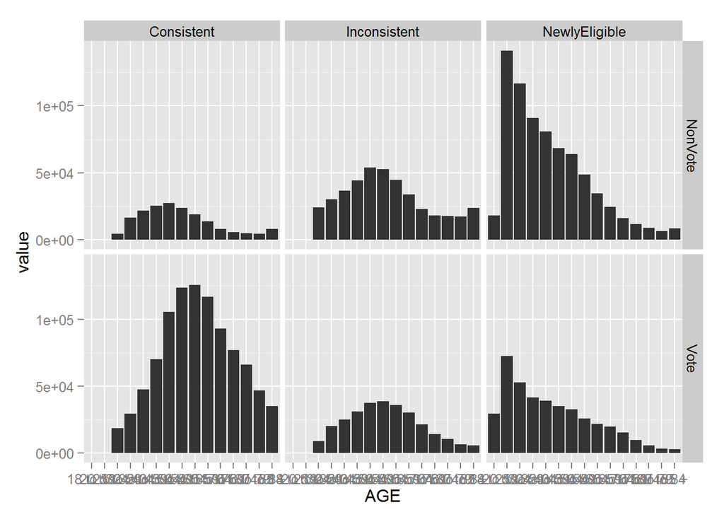

```r
# base plot == total voter count (y = value) by age group (x)
p1 <- ggplot(BCdata_long, aes(x = AGE, y = value)) +
  geom_bar(stat="identity")
# facet by pattern and vote 2009
p1 + facet_grid(vote09 ~ pattern)
```

```r
#
```

#### Cleveland Dot Plots

Simple plots, followed by the same plot with more elaborate formatting.

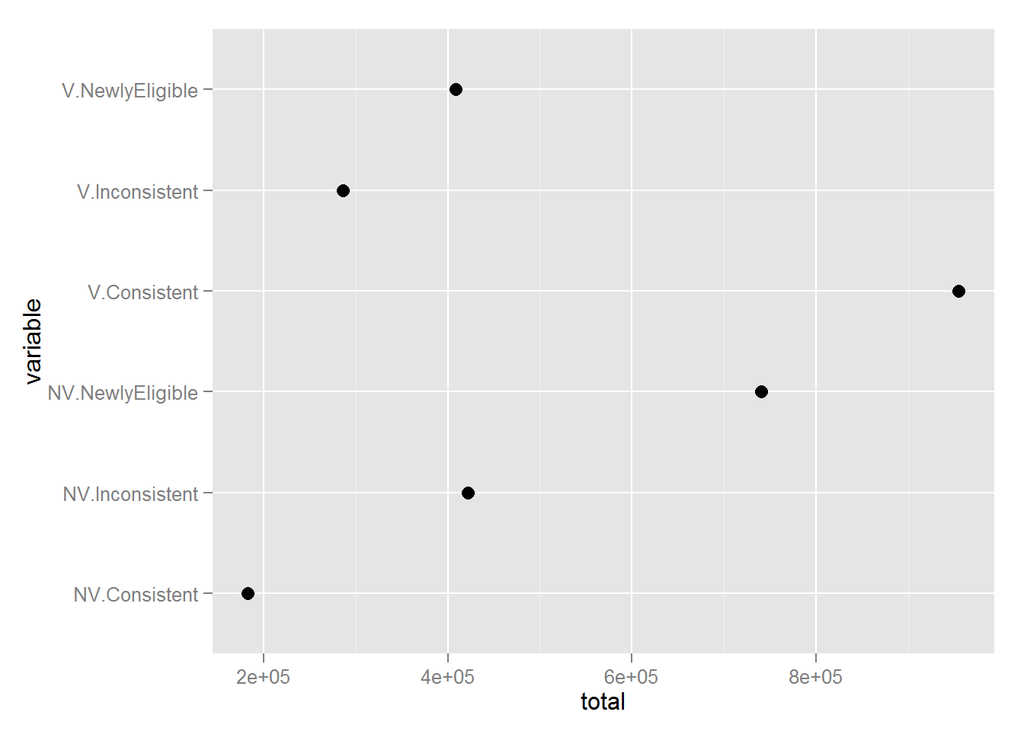

```r
# p2a = base plot with count
p2a <- ggplot(plot2data, aes(x = total, y = variable)) +
  geom_point(size=3)
p2a
```

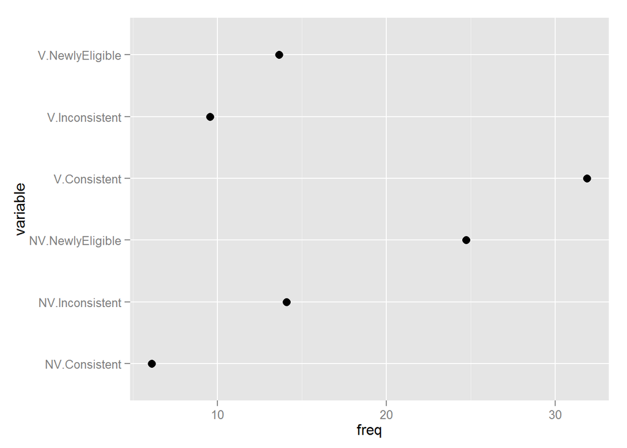

```r
# p2b = base plot with percentage ("freq")
p2b <- ggplot(plot2data, aes(x = freq, y = variable)) +
  geom_point(size=3)
p2b
```

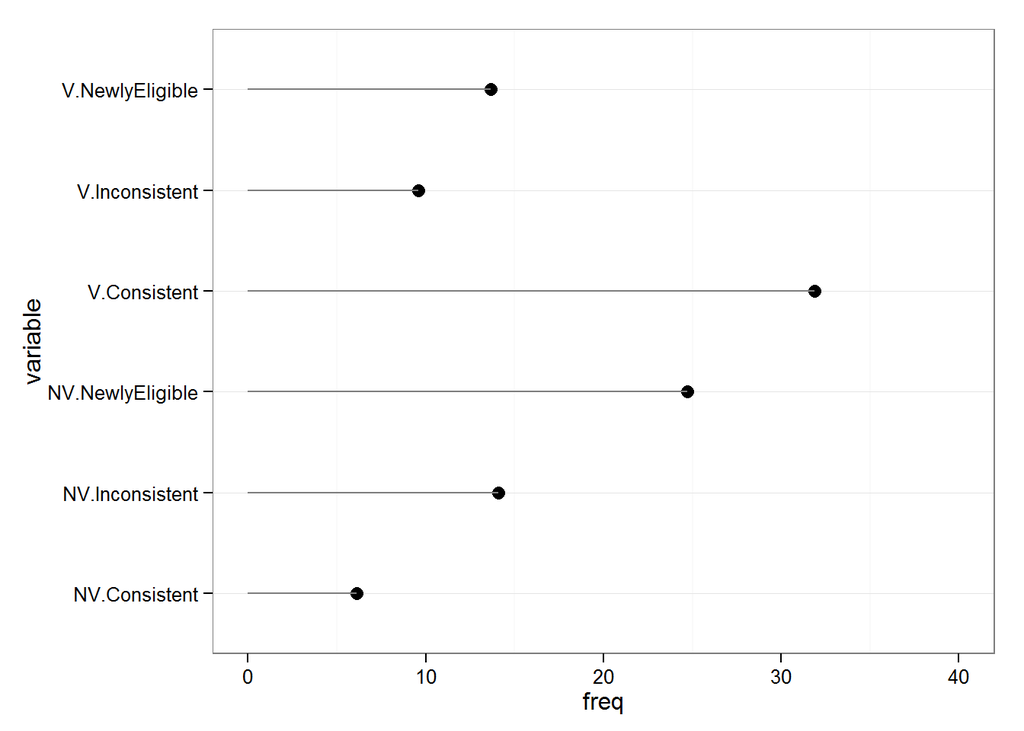

```r
# additional tweaks
p2 <- p2b # or p2a
p2 +
  theme_bw() +
  xlim(0, 40) +
  geom_segment(aes(yend=variable), xend=0, colour="grey50") +
  theme(panel.grid.major.x = element_blank())
```

```r
#
# sort, big to little
# p2c = base plot with percentage ("freq"), sorted
plot2data <- plot2data %>%
  arrange(freq)
plot2data
```

```
## Source: local data frame [6 x 3]
##
##           variable  total      freq
## 1    NV.Consistent 183147  6.114159
## 2   V.Inconsistent 286569  9.566787
## 3  V.NewlyEligible 408689 13.643628
## 4  NV.Inconsistent 421611 14.075014
## 5 NV.NewlyEligible 740229 24.711722
## 6     V.Consistent 955212 31.888690
```

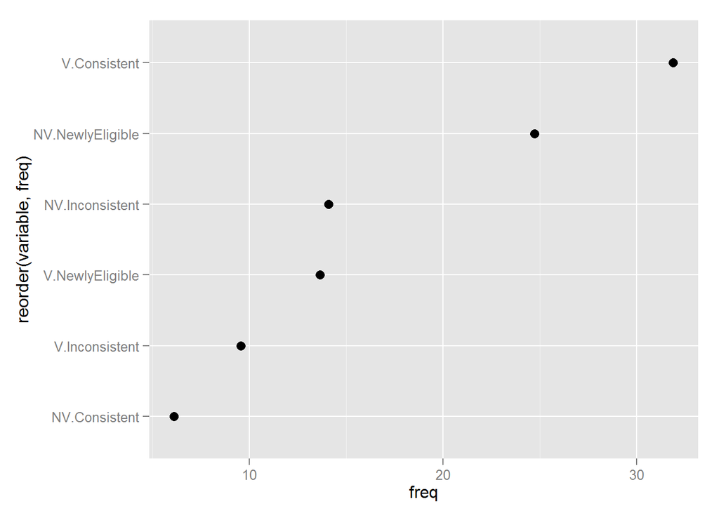

```r
p2c <- ggplot(plot2data,
              aes(x = freq, y = reorder(variable, freq))) +
  geom_point(size=3)
p2c
```

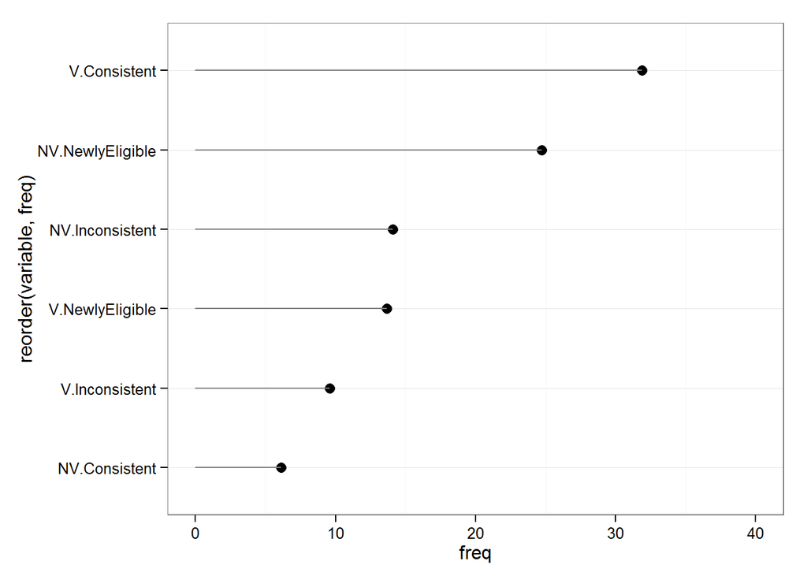

```r
p2 <- p2c

p2 +
  theme_bw() +
  xlim(0, 40) +
  geom_segment(aes(yend=variable), xend=0, colour="grey50") +
  theme(panel.grid.major.x = element_blank())
```

```r
#
```

The end

-30-